# 01_Data_Exploration

2025-06-24

## Load Metadata and Peak Files

```r
pheno <- read_csv("pheno.csv", show_col_types = FALSE)
```

```r
peak_folder <- "/mnt/IM/groupMansuy/theresa/ATAC/MSUS39F1/results_mm10/01_preprocess/10_filtered_peaks"
peak_files <- list.files(peak_folder, pattern = "_peaks.narrowPeak$", full.names = TRUE)
peak_ids <- gsub("_peaks.narrowPeak", "", basename(peak_files))
```

```r
stopifnot(all(peak_ids %in% pheno$Sample_file_name))
pheno_matched <- pheno[match(peak_ids, pheno$Sample_file_name), ]
```

## Peak Count QC

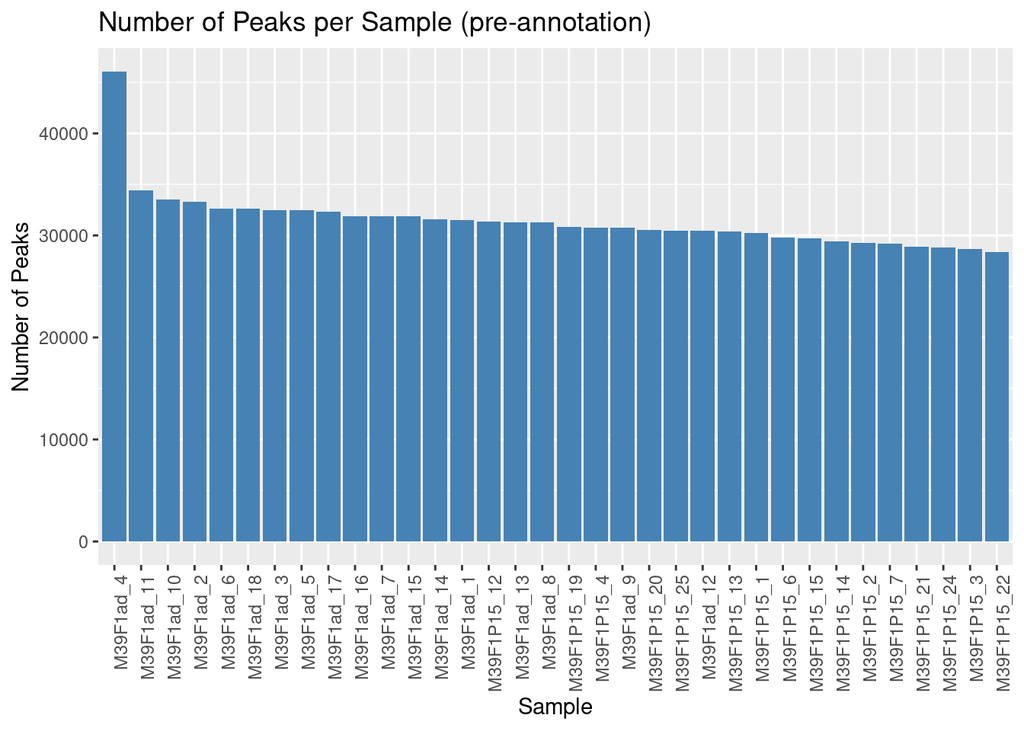

```r
peak_counts <- tibble(Sample = peak_ids, NumPeaks = sapply(peak_files, function(file) nrow(read.table(file)))); ggplot(peak_counts, aes(x = reorder(Sample, -NumPeaks), y = NumPeaks)) + geom_bar(stat = "identity", fill = "steelblue") + theme(axis.text.x = element_text(angle = 90, hjust = 1)) + xlab("Sample") + ylab("Number of Peaks") + ggtitle("Number of Peaks per Sample (pre-annotation)")
```

Most samples show consistent peak counts. Sample M39F1ad_4 has unusually high counts, possibly due to higher signal or sequencing depth.

## Library Complexity (NRF)

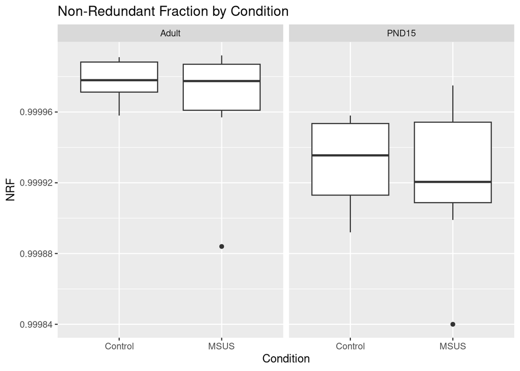

```r
ggplot(pheno, aes(x = Condition, y = NRF)) + geom_boxplot() + facet_wrap(~ Age) + ggtitle("Non-Redundant Fraction by Condition")
```

NRF values are high across samples, indicating good library complexity. Slight variability appears in the PND15 group, but no major differences exist between Control and MSUS.

## Genomic Annotation of Peaks

```r
annotations_list <- suppressMessages(lapply(peak_files, function(f) annotatePeak(readPeakFile(f), tssRegion = c(-3000, 3000), TxDb = TxDb.Mmusculus.UCSC.mm10.knownGene, annoDb = "org.Mm.eg.db", verbose = FALSE)))
```

```r
for (i in seq_along(annotations_list)) {
  annotations_list[[i]]@anno$Age <- pheno_matched$Age[i]
  annotations_list[[i]]@anno$Condition <- pheno_matched$Condition[i]
}
```

```r
names(annotations_list) <- peak_ids
```

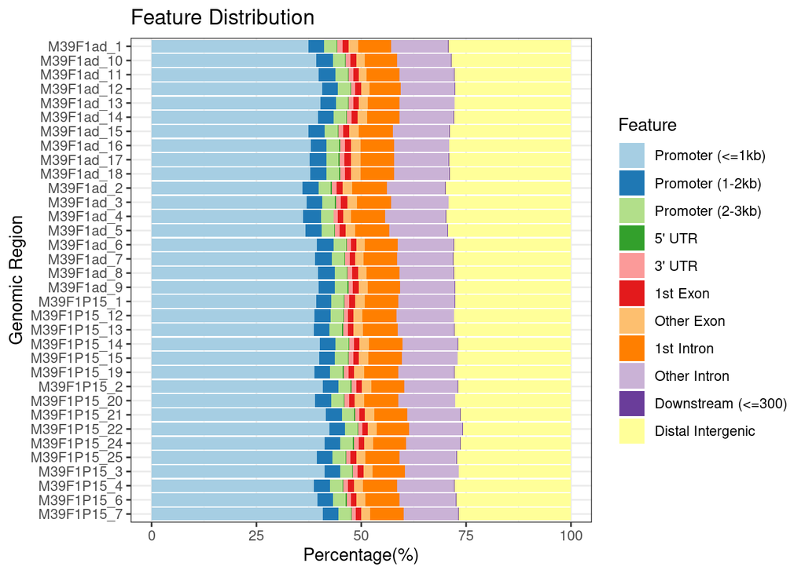

```r
plotAnnoBar(annotations_list, xlab = "Genomic Region", by = "Condition")
```

## Distance to TSS

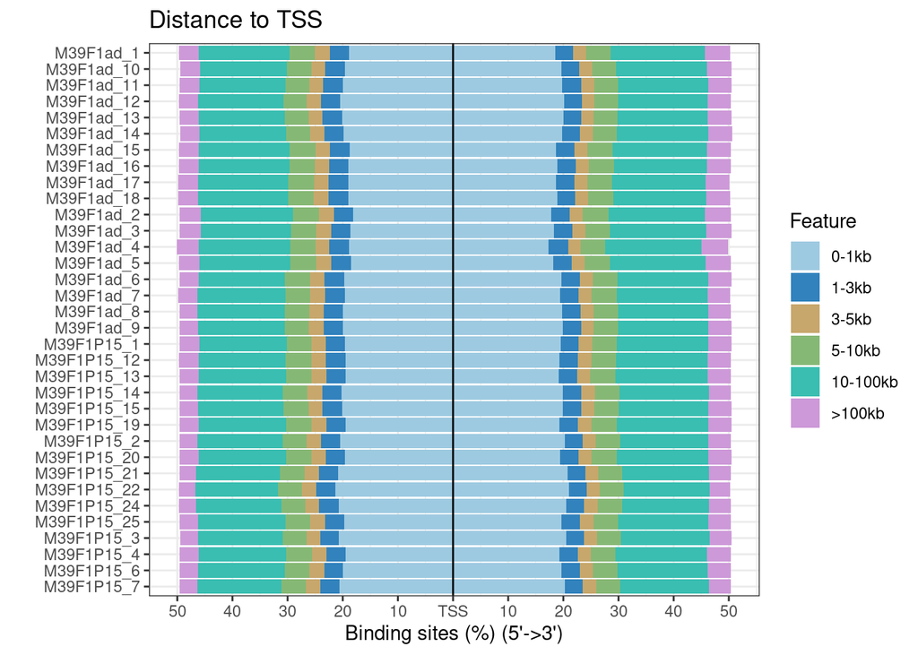

```r
plotDistToTSS(annotations_list, title = "Distance to TSS")
```

Many peaks cluster near the transcription start site (TSS), while others lie >10 kb away, suggesting distal regulatory elements. The symmetric distribution is typical for ATAC-seq and supports reliable peak detection.

## Read Counting (featureCounts)

```r
bam_files <- list.files("/mnt/groupMansuy/theresa/ATAC/MSUS39F1/results_mm10/01_preprocess/08_NF", pattern = "\\.bam$", full.names = TRUE)
combined_peaks <- reduce(do.call(c, lapply(list.files("/mnt/IM/groupMansuy/theresa/ATAC/MSUS39F1/results_mm10/01_preprocess/10_filtered_peaks", pattern = "_peaks.narrowPeak$", full.names = TRUE), import)))
```

```r
saf <- data.frame(GeneID = paste0("peak_", seq_along(combined_peaks)), Chr = as.character(seqnames(combined_peaks)), Start = start(combined_peaks), End = end(combined_peaks), Strand = "*")
write.table(saf, saf_file <- tempfile(fileext = ".saf"), sep = "\t", quote = FALSE, row.names = FALSE)
```

```r
invisible(capture.output(
  counts <- suppressMessages(featureCounts(
    files = bam_files, annot.ext = saf_file, isGTFAnnotationFile = FALSE,
    isPairedEnd = TRUE, nthreads = 4, verbose = FALSE
  ))
))
```

```r
counts_df <- as.data.frame(counts$counts)
colnames(counts_df) <- sub("\\.bam$", "", basename(bam_files))
counts_df$Peak <- saf$GeneID
```

## Variability Analysis

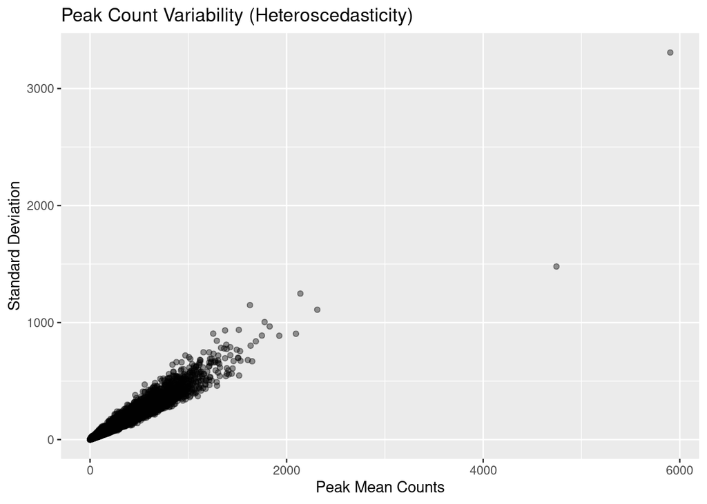

```r
ggplot(data.frame(m = rowMeans(counts_df[,-ncol(counts_df)]), s = apply(counts_df[,-ncol(counts_df)], 1, sd)),
       aes(x = m, y = s)) +
  geom_point(alpha = 0.4) +
  labs(x = "Peak Mean Counts", y = "Standard Deviation", title = "Peak Count Variability (Heteroscedasticity)")
```

The scatter plot displays each peak’s mean count vs. its variability (standard deviation) across samples. Peaks with higher average counts show more variability—a pattern known as heteroscedasticity, typical in ATAC-seq data. This highlights variation in signal strength and the need for normalization in downstream analyses.

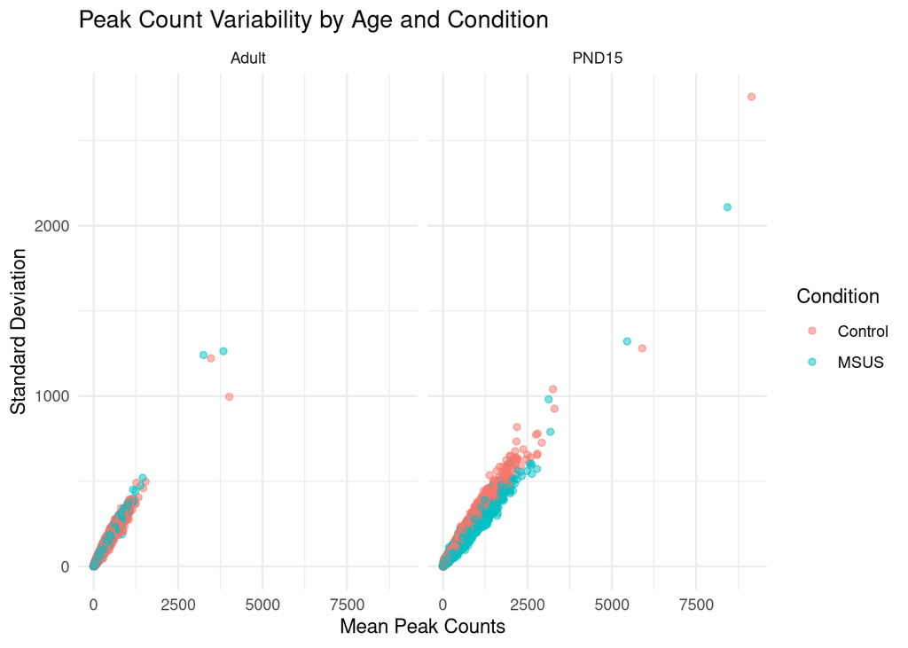

```r
group_summary <- counts_df |>
  pivot_longer(-Peak, names_to = "Sample", values_to = "Count") |>
  left_join(pheno_matched, by = c("Sample" = "Sample_file_name")) |>
  group_by(Peak, Age, Condition) |>
  summarise(mean = mean(Count), sd = sd(Count), .groups = "drop")

ggplot(group_summary, aes(x = mean, y = sd, color = Condition)) +
  geom_point(alpha = 0.5) +
  facet_wrap(~Age) +
  labs(x = "Mean Peak Counts", y = "Standard Deviation", title = "Peak Count Variability by Age and Condition") +
  theme_minimal()
```

Variability increases with peak counts across all groups, showing expected heteroscedasticity. No major differences are seen between Control and MSUS, though PND15 samples show slightly more spread.